# Análisis de la desinformación y la migración

hun_longchong

2025-01-28

## Introducción y marco teórico

### Contextualización del tema

La inmigración como situación de ámbito global, ha significado un objeto de fuertes discusiones en los presentes años, a partir de eso, las plataformas digitales, sus distintos usuarios y comunidades de estas, han representado en gran medida emisores de todo tipos de argumentos e información errónea, que sin lugar a duda afecta la visión que existe sobre las personas migrantes, siendo España y sus jóvenes parte de esta problemática, estando estos expuestos a contenidos fuera de contexto y una cantidad importante de información sesgada y sin fuentes que las respalden, contribuyendo como resultado, a que se produzcan estigmas, racismo y discriminación.

Cabe resaltar, que este objeto de estudio es primordial, ya que teniendo en cuenta lo que piensan los jóvenes sobre el fenómeno migratorio, será la imagen del tipo de sociedad que podríamos tener a mediano plazo, esto, debido a la creciente alza de políticas que están contemplando países como Estados Unidos, Italia y Alemania, que podría afectar también reflejarse en España, y las diversas formas ideológicas y movimientos culturales que convergen en su realidad social.

### Justificación del estudio

La justificación de la realización de este estudio se basa en la necesidad de desarrollar un sustento informativo respecto a la inmigración, enfocado a un público juvenil, para combatir la falsa comunicación respecto a un tema social de actual debate y de una problemática ética.

Teniendo en cuenta la situación política actual del país, enfrentado en materias económicas y estructurales, el ámbito social se rige en gran parte por la opinión pública; generalmente condicionada por una desinformación global presentada por los medios de comunicación y la propagación de bulos en las redes sociales. El proyecto busca solucionar dicha problemática abordándola desde la perspectiva más teórica para, a continuación, proponer una aplicación que sirva como posible solución; lo cual explica la ejecución del trabajo.

Por último, la argumentación de esta investigación versa en la necesidad de separar un conflicto social de sus connotaciones ideológicas, abordando la problemática desde distintas perspectivas y opiniones para poder concluir en un contenido que sirva como marco referencial informativo ajeno a dichas valoraciones personales y explique de la forma más objetiva posible cuales son los conflictos relacionados con la inmigración en España, principalmente mediante la aplicación.

### Objetivos del trabajo

**Objetivos específicos:**

-Analizar cómo la desinformación en redes sociales en usuarios de 18 a 27 años españoles afecta las actitudes del grupo etario hacia la inmigración y las políticas públicas al respecto.

-Mostrar como desde los medios audiovisuales y narrativas digitales se pueden abordar problemas de desinformación sobre inmigración.

### Revisión de literatura y conceptos clave

Conceptos Claves- Keywords Desinformación, Percepción, Migración , Jóvenes, España. Exposición de los antecedentes teóricos y empíricos más relevantes, incluyendo definiciones fundamentales y teorías base.

Para el desarrollo del trabajo hemos llevado a cabo una búsqueda de información exhaustiva que sirve de precedente para los temas que vamos a tratar, cubriendo todos los aspectos principales en forma de contexto informativo.

Primeramente, como base para el impacto del fenómeno inmigratorio en el ámbito nacional, se ha consultado documentación con una perspectiva crítica de la problemática, con foco en los perfiles más recurrentes y las situaciones en las que se encuentran. Centradas en la fisonomía del conflicto, sirven como marco teórico base del trabajo (Arango, 2002). A pesar de ser documentación pasada, sirve de referencia por su modelo adecuado a la actualidad. Aún así, para contrastar tal información, hemos consultado informes más actuales que abordan el tratamiento informativo de la migración desde una perspectiva jurídico-periodística (Ortega, 2024).

Por otro lado, en forma de antecedente, hemos recurrido a textos que abarquen las partes interesadas, por el valor de su opinión, sobre el discurso mediático acerca de la migración a partir de la pandemia (época en la cual aumentó el odio hacia los inmigrantes) (García Bueno y Hänninen, 2024). Siguiendo la línea de las valoraciones sociales, referimos a documentación sobre el predominio de ciertas actitudes poblacionales con vinculación al racismo y la xenofobia, refiriéndo a como tales idearios condicionan las posturas de algunos partidos, con consecuencia directa a la información que se divulga (Rinken, 2021).

Por último, el documento llamado “La agenda que queda fuera de los medios. Desinformación y «fact-checking» sobre (in)migración”, servirá como referencia principal para el desarrollo y la vinculación del conflicto inmigratorio con la problemática de la desinformación, pues abarca ambos temas en profundidad (Magallón, 2021).

En base a la documentación mencionada, se propone el siguiente texto como marco teórico principal:

El fenómeno de la desinformación sobre inmigración está profundamente ligado al auge de discursos xenófobos que encuentran en las redes sociales un espacio privilegiado para su difusión, muchas veces al margen del escrutinio de los medios tradicionales. Este tipo de contenido no solo refuerza narrativas polarizantes, sino que influye directamente en la percepción social sobre la inmigración, moldeando actitudes que oscilan entre la tolerancia y el rechazo manifiesto.

Según investigaciones recientes, mientras que las actitudes mayoritarias hacia la inmigración en España han sido descritas como excepcionalmente benévolas incluso durante crisis económicas, la emergencia de discursos anti inmigrantes en el ámbito político ha comenzado a transformar este panorama, visibilizando un trasfondo de hostilidad latente que podría haber sido previamente subestimado por presiones de deseabilidad social.

Además, el tratamiento mediático de eventos críticos, como la tragedia de Nador en 2022, pone de manifiesto cómo el uso de terminologías inadecuadas y enfoques dicotómicos “nosotros-ellos” perpetúan narrativas que deshumanizan a las personas migrantes, limitando su representación justa y equitativa en la esfera pública.

Desde una perspectiva histórica y estructural, el carácter reciente de la inmigración en España, marcado por su diversidad, juventud y altas tasas de irregularidad, ha contribuido a su inserción laboral precaria y a la exclusión social, elementos que a menudo son explotados por campañas de desinformación para generar alarma social. Estas dinámicas subrayan la necesidad de un enfoque interdisciplinar que incorpore tanto datos empíricos como análisis narrativos para comprender y contrarrestar los efectos de la desinformación en la percepción de la ciudadanía, especialmente en jóvenes expuestos a estas narrativas en redes sociales.

## Metodología empleada

### Enfoque metodológico

Con respecto al enfoque metodológico que se utilizó para este estudio, se determinó uno mixto, debido a la necesidad de emplear métodos tanto de tipo cualitativo, como la revisión bibliográfica y el contraste de fuentes expertas. Al mismo tiempo, se prefirieron técnicas estadísticas –propias de un enfoque cualitativo– para medir el impacto de la desinformación en la actitud de la audiencia joven frente a la inmigración en España, como también rasgos propios del discurso de la desinformación.

### Diseño de investigación

Se prefirió un diseño de investigación exploratoria, ya que la intención principal era conocer las características del fenómeno en cuestión. Si bien la investigación exploratoria suele emplearse con objetos de estudio poco conocidos y la producción teórica sobre desinformación, como ya se apuntó antes, no es escasa, los objetivos planteados demandaron un acercamiento de este tipo.

### Técnicas y herramientas de recolección de datos

Para la realización de este estudio se realizó una recopilación de artículos académicos e informes de organizaciones especializadas en el fenómeno, los cuáles permitieron contextualizar y entender de forma exhaustiva la inmigración como situación de ámbito global y el impacto de la desinformación en redes sociales en la percepción de ciudadanos jóvenes sobre este tema.

Parte fundamental de los datos empleados en este análisis fueron recopilados por la empresa 40dB para las compañías mediáticas El País y Cadena SER, pertenecientes al Grupo Prisa, y publicados junto a su informe sobre percepciones sobre la inmigración en la población española. Es importante señalar que, si bien existe un informe similar del Centro de Investigaciones Sociológicas, se prefirió el informe de 40dB por incluir este datos sobre identificación de noticias falsas y vías de consumo informativo.

Además, se incorporaron datos recopilados por Narváez Llinares y Pérez-Rufí (2022) sobre características del discurso xenófobo en redes sociales y medios online, con énfasis en la desinformación, datos a su vez recopilados de la plataforma de *fact-checking* “Maldita Migración”.

Para las operaciones y el análisis estadísticos, además de la presentación de los datos en tablas y gráficos, se empleó el lenguaje de programación abierto R con las librerías GGally, kableExtra, scales, ggplot2, stringr, forcats, dplyr, tidyr, readr, httr, RCurl, stats, graphics, grDevices, utils, datasets, methods y base. Para la compilación del informe en formato pdf se empleó Rmarkdown de conjunto con TinyTeX, una distribución de LaTeX para R.

Los datos recopilados por Narváez Llinares y Pérez-Rufí fueron obtenidos directamente del artículo y volcados en formato de datos separados pro comas (csv) gracias a la herramienta *open-source* Tabula.

### Procedimiento de análisis

Primeramente, se realizó una recolección bibliográfica y se contrastaron fuentes de expertos en el fenómeno de la desinformación respecto al tema de inmigratorio. Seguido, se analizó la encuesta realizada por la empresa 40dB mediante un análisis estadístico descriptivo. Por último, se incluyeron los datos analizados por Narváez Llinares y Pérez-Rufí.

Para medir qué tan probable un usuario está en riesgo de confundir una noticia falsa como verdadera, partimos de una reinterpretación de la pregunta 16 de la encuesta: *¿en qué medida crees que se publican informaciones falsas sobre inmigración?*. Asumimos en beneficio del análisis que una menor percepción en el volumen de noticias falsas circulando implica un mayor riesgo de consumirlas como verdaderas.

Con el fin de analizar la relación entre las variables observadas, se optó por la identificar patrones mediante medidas de tendencia central (moda, mediana, media) y análisis de correlaciones. Esto implicó adaptar variables cualitativas categóricas a escalas numéricas, siguiendo una lógica similar a la que ya emplea la encuesta para la autoidentificación política. La tabla siguiente ilustra la escala original y su adecuación numérica:

[output not shown]

## Resultados del diagnóstico

### Descripción de los hallazgos principales

#### Rasgos de la desinformación sobre inmigración

De acuerdo con Narváez Llinares y Pérez-Rufí, los ejemplos de desinformación estudiados se basan en estereotipos y discursos de odio hacia los migrantes, que se repiten de forma recurrente. Estos discursos suelen presentar a los migrantes como delincuentes o violentos (37.7%), como perceptores de ayudas económicas de manera preferencial (28.3%), o como una amenaza a las tradiciones culturales y religiosas españolas (26.4%).

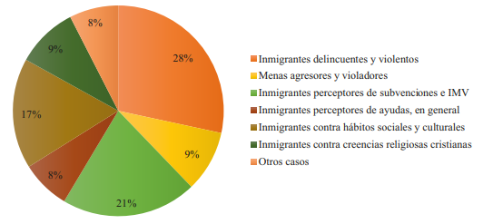

Si bien los bulos son capaz de actualizarse en relación con el contexto informativo, cerca de un 22% de los contenidos identificados fueron “noticas zombie”, es decir, noticias que recirculan en más de una ocasión y que necesitan ser desmentidas en más de una ocasión.

Los ejemplos analizados atacaban principalmente a grupos poco precisos, mezclando nacionalidad o continente (marroquí, “moro”, africano) con creencias religiosas (musulmana) o color de piel (personas negras). Los grupos más mencionados son: personas de origen marroquí o musulmán (36%), personas subsaharianas (18%), y refugiados ucranianos (14%). En un 32% de los casos, no se especificaba el origen de los migrantes.

Las redes sociales, de forma poco sorpresiva, representan el principal canal de distribución de la desinformación, con un 87% de los casos. Twitter es a plataforma más representada en la muestra (45%), seguida por WhatsApp (8.6%), Facebook (4.3%), y otras. Sin embargo, resulta preocupante que un 13% de los canales de difusión correspondieron a páginas web que se presentan como medios informativos.

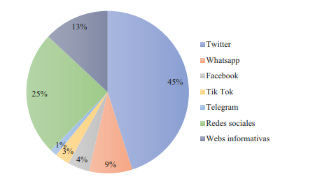

La desinformación se difunde principalmente a través de texto (90%), aunque el 72% de los casos combina texto con contenido visual (imagen o video) o sonoro (audio). El video se utiliza en el 44% de los casos.

La mayoría de los contenidos son fabricados (52%) o manipulados (46%), lo que indica una clara intención de engaño. El 16% de los casos utilizan fuentes impostoras, principalmente suplantando a medios de información.

#### Consumo y efectos de la desinformación

###### Composición de la muestra

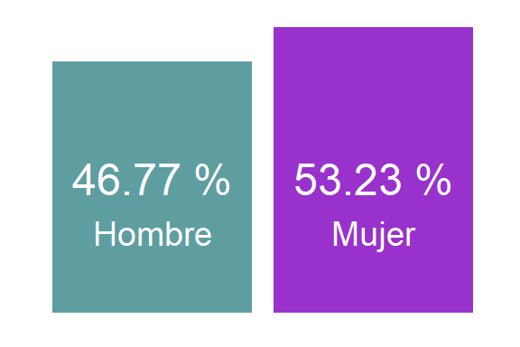

Composición por edad

| Min. | Q1 | Mediana | Media | Q3 | Max. | Coef.Var | n |
| --- | --- | --- | --- | --- | --- | --- | --- |
| 18 | 21 | 24 | 22.9 | 25 | 27 | 11.67 | 248 |

Composición por Comunidades Autónomas

| Comuniadades Autónomas | n |
| --- | --- |
| Andalucía | 53 |
| Aragón | 6 |
| Asturias, Principado de | 2 |
| Balears, Illes | 3 |
| Canarias | 12 |
| Cantabria | 3 |
| Castilla - La Mancha | 11 |
| Castilla y León | 6 |
| Cataluña | 36 |
| Comunitat Valenciana | 34 |
| Extremadura | 11 |
| Galicia | 15 |
| Madrid, Comunidad de | 30 |
| Murcia, Región de | 7 |
| Navarra, Comunidad Foral de | 4 |
| País Vasco | 13 |
| Rioja, La | 2 |

Composición por situación económica

| Situación económica | n |
| --- | --- |
| Ahorro/se ahorra bastante dinero cada mes | 62 |
| Ahorro/se ahorra un poco de dinero cada mes | 118 |
| He tenido/se ha tenido que contraer deuda | 6 |
| He tenido/se ha tenido que echar mano del ahorro | 9 |
| Llego/se llega justo a final de mes | 53 |

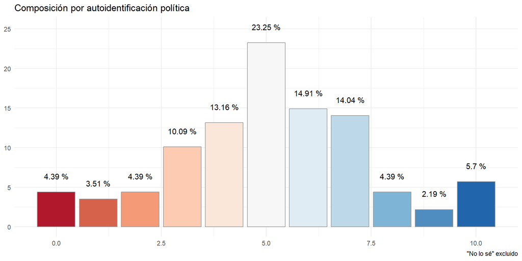

| Min. | Q1 | Mediana | Media | Q3 | Max. | Coef.Var | n |
| --- | --- | --- | --- | --- | --- | --- | --- |
| 0 | 4 | 5 | 5.11 | 7 | 10 | 45.82 | 228 |

###### Fuentes de información sobre la inmigración

En términos generales, los medios no digitales (55.68%) superan a los digitales (42.73%), aunque estos últimos muestran un peso considerable, lo que reafirma que la información sobre la inmigración, sea esta o no verídica, se difunde a través de múltiples vías.

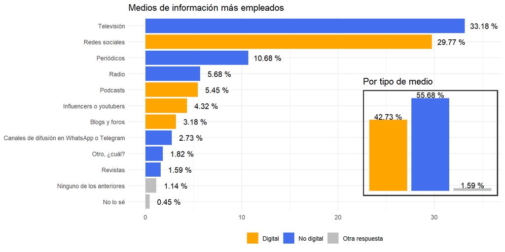

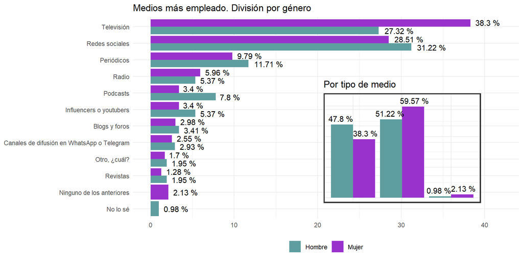

###### Cruce de variables

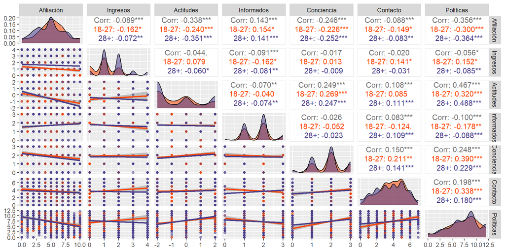

Los resultados indican una correlación positiva entre la consciencia respecto a la desinformación y las actitudes frente los inmigrantes: a medida que aumenta la conciencia sobre la desinformación, las actitudes hacia la inmigración tienden a ser más favorables. Del mismo modo, la correlación positiva entre la conciencia y el apoyo a políticas migratorias indica que quienes están más alertas sobre la desinformación son también individuos más propensos a respaldar políticas de apoyo a los inmigrantes.